# Single Cell RNA-seq Classification - Cuomo et al 2020

The single-cell RNA-seq data used in this example comes from the Cuomo et al 2020 paper (https://www.nature.com/articles/s41467-020-14457-z). The expression levels have been normalised using SCTransform (https://genomebiology.biomedcentral.com/articles/10.1186/s13059-019-1874-1). Cells were clustered using Seurat (https://satijalab.org/seurat/). Here, we are only considering cells from day 3, coming from donors hayt, melw and naah. 500 (non-constant) genes have been selected at random to lower the time requirements. We will attempt to classify cells into 3 predefined cell types.

```r
if(!require(caret)){install.packages("caret")}
library(caret)
if(!require(ggplot2)){install.packages("ggplot2")}
library(ggplot2)
if(!require(UpSetR)){install.packages("UpsetR")}
library(UpSetR)
if(!require(GGally)){install.packages("GGally")}
library(GGally)
if(!require(rpart.plot)){install.packages("rpart.plot")}
library(rpart.plot)
if(!require(Rtsne)){install.packages("Rtsne")}
library(Rtsne)
if(!require(dplyr)){install.packages("dplyr")}
library(dplyr)
if(!require(randomForest)){install.packages("randomForest")}
library(randomForest)
```

## Loading data

```r
cuomo = read.csv('Cuomo2020_ML.csv',row.names = 1)
cuomoData = cuomo[,colnames(cuomo)[colnames(cuomo)!='classification']]
cuomoClass = cuomo$classification
```

## Initial visualisation

Pick a few genes and plot the distribution of expression for that gene in each cluster.

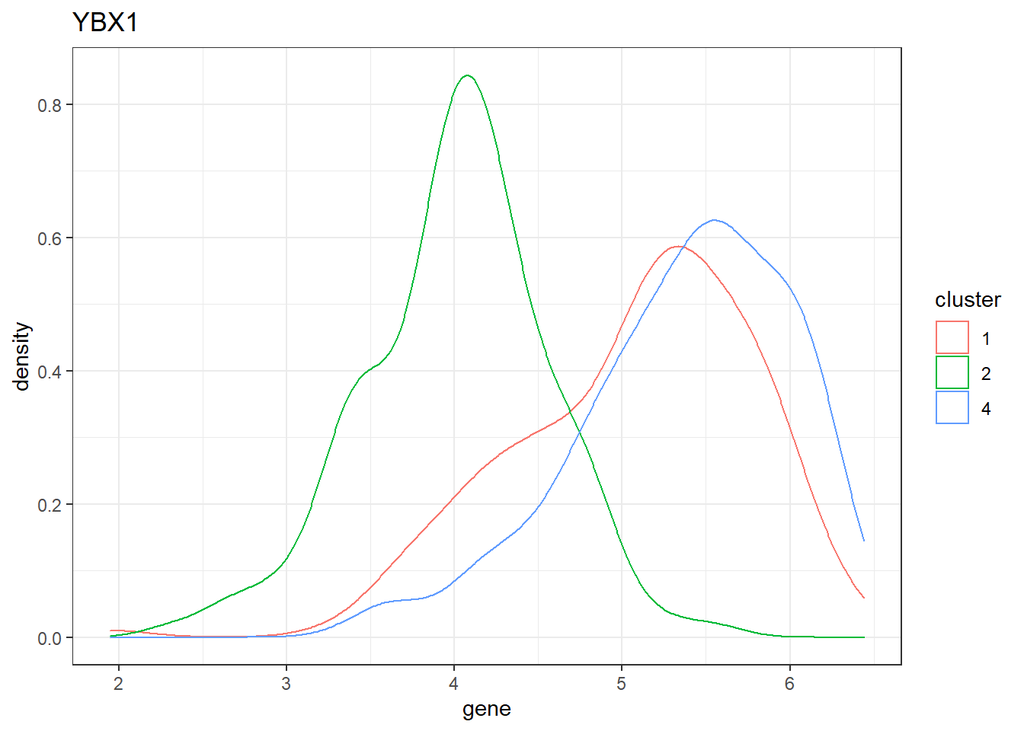

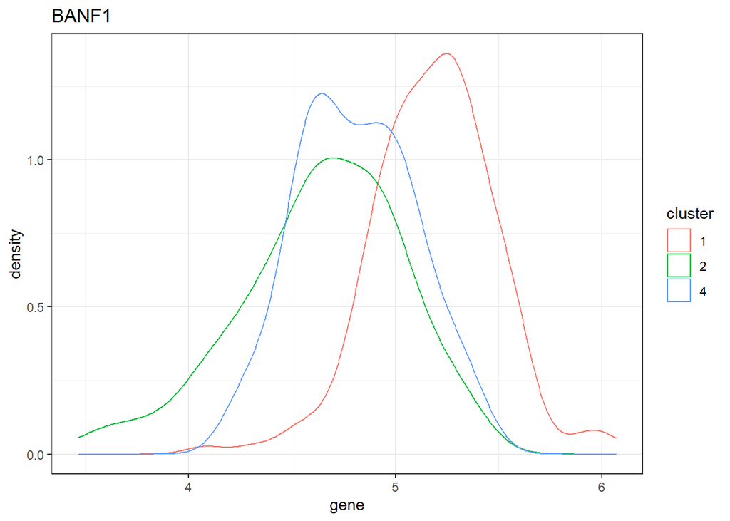

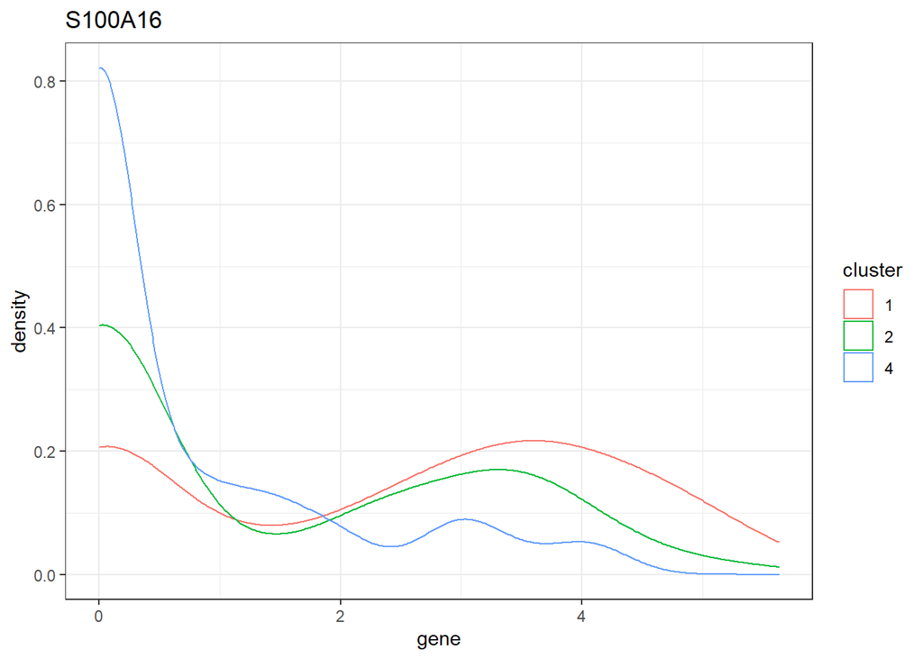

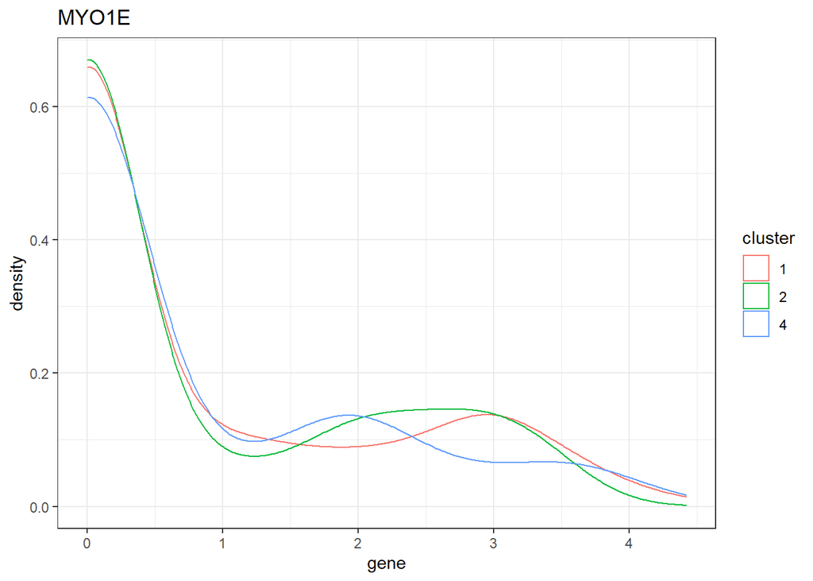

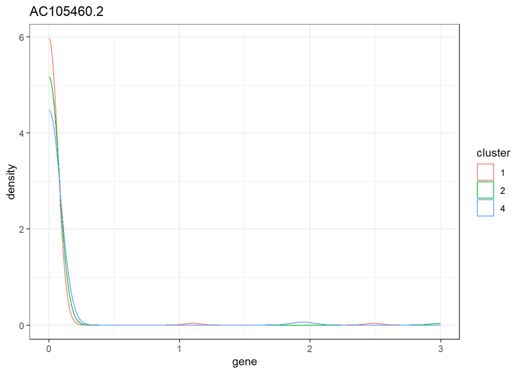

```r
set.seed(42)
some.genes = c("YBX1","BANF1","S100A16","MYO1E","AC105460.2")
for (gene in some.genes){
  plot.df = data.frame('cluster'=as.factor(cuomoClass),'gene'=cuomoData[,gene])
  print(ggplot(plot.df,aes(x=gene,y=..density..,color=cluster))+geom_density()+ggtitle(gene)+theme_bw())
}
```

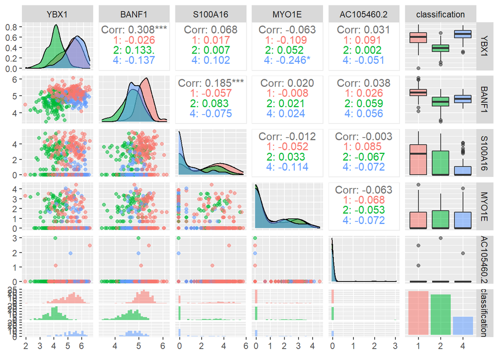

```r
pairs.df = cuomo[,c(some.genes,'classification')]
pairs.df$classification = as.factor(pairs.df$classification)

#pdf('ggpairs_5genes.pdf', width=10, height=10)
ggpairs(pairs.df,mapping = aes(colour=classification,alpha=0.5))
```

```r
#dev.off()
```

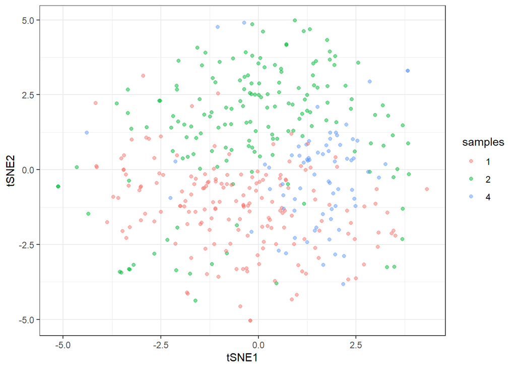

```r
cuomoTsne <- Rtsne(cuomoData, check_duplicates=FALSE, pca=TRUE, perplexity=50, theta=0.5, dims=2)
print(cuomoTsne$Y %>%
  as.data.frame() %>%
  rename(tSNE1=V1,  tSNE2=V2) %>%
  mutate( samples=as.character(cuomoClass) )%>%
  ggplot() +
  geom_point( mapping = aes(x=tSNE1, y=tSNE2, color=samples), alpha=0.5) +
  theme_bw())
```

## Preprocessing

### Highly correlated variables

Identify highly correlated variables.

```r
corMat <- cor(cuomoData)
highCorr <- findCorrelation(corMat, cutoff=0.5)
highly.correlated = names(cuomoData)[highCorr]
print(length(highly.correlated))
```

```
## [1] 39
```

```r
print(head(highly.correlated))
```

```
## [1] "AC105460.2" "BX293535.1" "ST8SIA5"    "AC037459.4" "AC146949.1"
## [6] "UBL5"
```

### Zero and near-zero variance variables

Identify zero and near zero variance variables.

```r
nzv <- nearZeroVar(cuomoData, saveMetrics=T)
near.zero.variance = rownames(nzv[nzv$nzv==TRUE | nzv$zeroVar==TRUE,])
print(length(near.zero.variance))
```

```
## [1] 330
```

```r
print(head(near.zero.variance))
```

```
## [1] "MEIS3P2"     "ADRA2B"      "SNORD116.11" "STAU2.AS1"   "AC008532.1"
## [6] "ACE2"
```

### Split into training and test

Remove bad variables (highly correlated and zero/near zero variance) and split into 70% training and 30% test.

```r
features.to.exclude = unique(c(highly.correlated,near.zero.variance))
print(length(features.to.exclude))
```

```
## [1] 332
```

```r
cuomoData = cuomoData[,!(colnames(cuomoData)%in%features.to.exclude)]

set.seed(42)
trainIndex <- createDataPartition(y=cuomoClass, times=1, p=0.7, list=F)
classTrain <- as.factor(cuomoClass[trainIndex])
dataTrain <- cuomoData[trainIndex,]
classTest <- as.factor(cuomoClass[-trainIndex])
dataTest <- cuomoData[-trainIndex,]
```

### Set up cross-validation

Set up 10-fold cross-validation and set seeds for all classification

```r
set.seed(42)
seeds <- vector(mode = "list", length = 11)
for(i in 1:10) seeds[[i]] <- sample.int(1000, 75)
seeds[[11]] <- sample.int(1000,1)

train_ctrl <- trainControl(method="cv",
                           number = 10,
                           preProcOptions=list(cutoff=0.75),
                           seeds = seeds)
```

## Classifiers

### k-Nearest Neighbours

Run k-NN with k ranging from 1 to 50.

```r
tuneParam <- data.frame(k=seq(1,50,2))
knnFit <- train(dataTrain, classTrain,
                method="knn",
                preProcess = c("center", "scale"),
                tuneGrid=tuneParam,
                trControl=train_ctrl)

knnFit
```

```
## k-Nearest Neighbors
##
## 287 samples
## 168 predictors
##   3 classes: '1', '2', '4'
##
## Pre-processing: centered (168), scaled (168)
## Resampling: Cross-Validated (10 fold)
## Summary of sample sizes: 258, 258, 259, 258, 259, 258, ...
## Resampling results across tuning parameters:
##
##   k   Accuracy   Kappa
##    1  0.6451806  0.4463377
##    3  0.6490148  0.4529455
##    5  0.7051806  0.5334204
```

[output cut: 25 more lines]

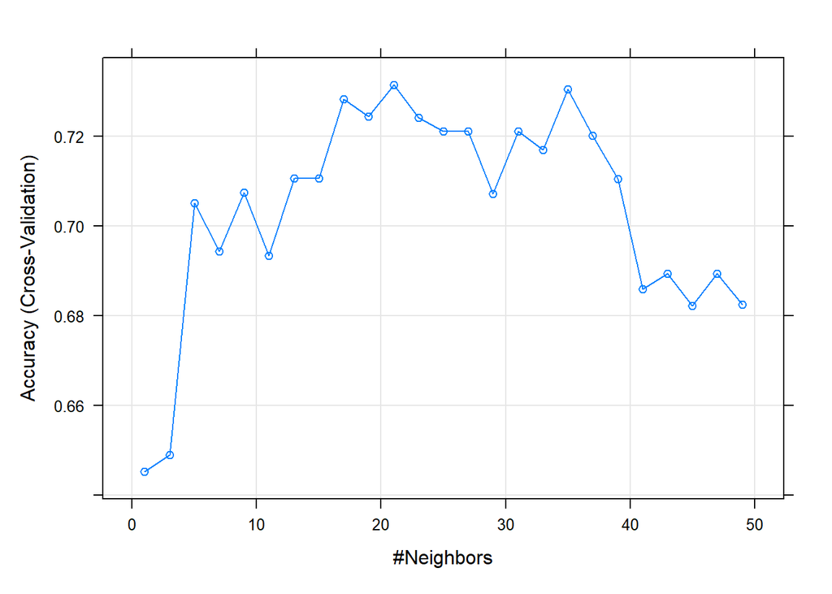

```r
plot(knnFit)
```

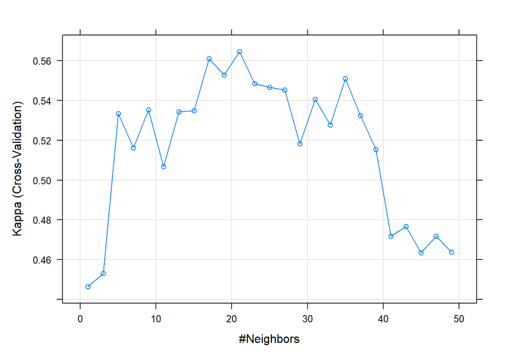

```r
plot(knnFit,metric="Kappa")
```

```r
test_pred <- predict(knnFit, dataTest)
confusionMatrix(test_pred, classTest)
```

```
## Confusion Matrix and Statistics
##
##           Reference
## Prediction  1  2  4
##          1 49 16  7
##          2  0 21  1
##          4  1 13 13
##
## Overall Statistics
##
##                Accuracy : 0.686
##                  95% CI : (0.5953, 0.7673)
##     No Information Rate : 0.4132
##     P-Value [Acc > NIR] : 1.265e-09
##
##                   Kappa : 0.5095
##
##  Mcnemar's Test P-Value : 9.431e-07
##
## Statistics by Class:
##
##                      Class: 1 Class: 2 Class: 4
## Sensitivity            0.9800   0.4200   0.6190
## Specificity            0.6761   0.9859   0.8600
## Pos Pred Value         0.6806   0.9545   0.4815
## Neg Pred Value         0.9796   0.7071   0.9149
## Prevalence             0.4132   0.4132   0.1736
## Detection Rate         0.4050   0.1736   0.1074
## Detection Prevalence   0.5950   0.1818   0.2231
## Balanced Accuracy      0.8280   0.7030   0.7395
```

Identify top 10 variables in kNN.

```r
knnFeat = varImp(knnFit)$importance
knnFeatures = head(rownames(knnFeat[order(-rowSums(knnFeat)),]),10)
print(knnFeatures)
```

```
##  [1] "YBX1"     "BANF1"    "CDC42EP1" "EEF2"     "ATF7IP"   "PRDX2"
##  [7] "OIP5.AS1" "NACA3P"   "ATP5MC2"  "VASP"
```

Try training kNN on top 10 features.

```r
dataTrain_topfeat = dataTrain[,knnFeatures]
dataTest_topfeat = dataTest[,knnFeatures]
knnFit_topfeat <- train(dataTrain_topfeat, classTrain,
               method="knn",
               tuneGrid=tuneParam,
               trControl=train_ctrl)
knnFit_topfeat
```

```
## k-Nearest Neighbors
##
## 287 samples
##  10 predictor
##   3 classes: '1', '2', '4'
##
## No pre-processing
## Resampling: Cross-Validated (10 fold)
## Summary of sample sizes: 257, 259, 258, 259, 258, 259, ...
## Resampling results across tuning parameters:
##
##   k   Accuracy   Kappa
##    1  0.7641544  0.6250234
##    3  0.7775944  0.6436503
##    5  0.7810345  0.6492207
```

[output cut: 25 more lines]

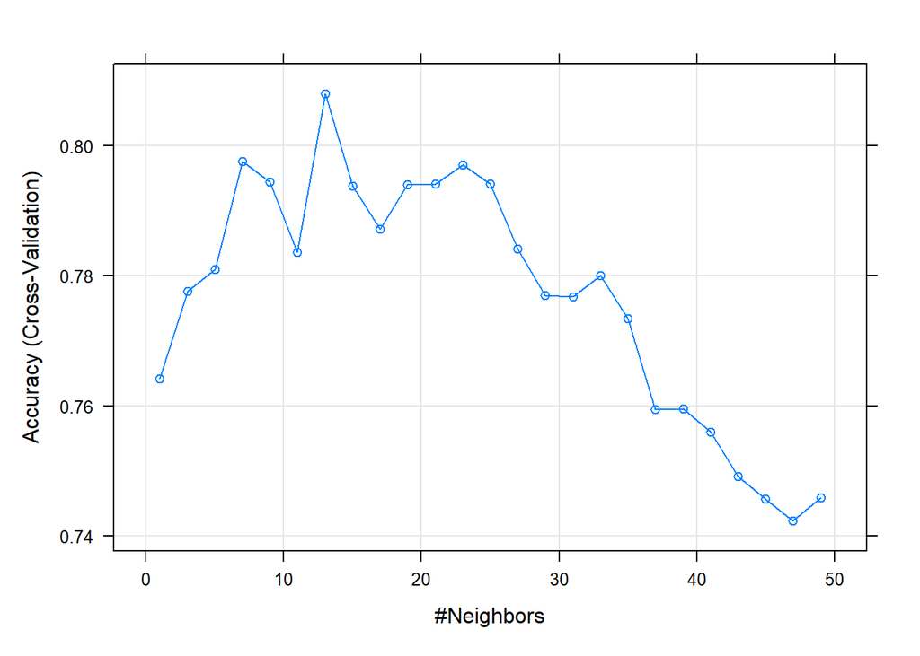

```r
plot(knnFit_topfeat)
```

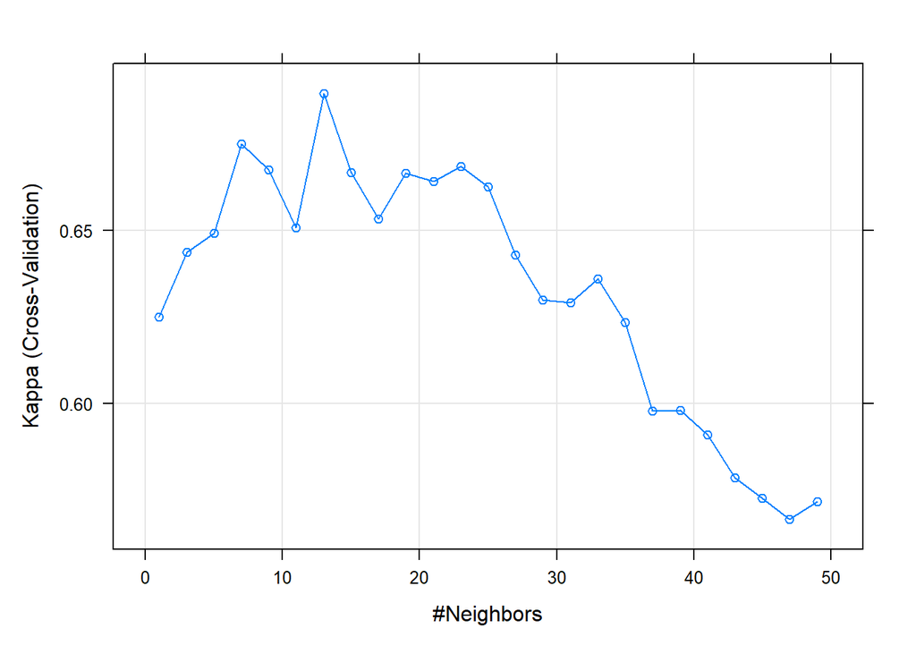

```r
plot(knnFit_topfeat,metric="Kappa")
```

```r
test_pred <- predict(knnFit_topfeat, dataTest_topfeat)
confusionMatrix(test_pred, classTest)
```

```
## Confusion Matrix and Statistics
##
##           Reference
## Prediction  1  2  4
##          1 38  0  9
##          2  6 48  2
##          4  6  2 10
##
## Overall Statistics
##
##                Accuracy : 0.7934
##                  95% CI : (0.7103, 0.8616)
##     No Information Rate : 0.4132
##     P-Value [Acc > NIR] : <2e-16
##
##                   Kappa : 0.6681
##
##  Mcnemar's Test P-Value : 0.0858
##
## Statistics by Class:
##
##                      Class: 1 Class: 2 Class: 4
## Sensitivity            0.7600   0.9600  0.47619
## Specificity            0.8732   0.8873  0.92000
## Pos Pred Value         0.8085   0.8571  0.55556
## Neg Pred Value         0.8378   0.9692  0.89320
## Prevalence             0.4132   0.4132  0.17355
## Detection Rate         0.3140   0.3967  0.08264
## Detection Prevalence   0.3884   0.4628  0.14876
## Balanced Accuracy      0.8166   0.9237  0.69810
```

### Decision Tree

```r
dtFit <- train(dataTrain, classTrain,
               method="rpart",
               tuneLength=10,
               trControl=train_ctrl)
dtFit
```

```
## CART
##
## 287 samples
## 168 predictors
##   3 classes: '1', '2', '4'
##
## No pre-processing
## Resampling: Cross-Validated (10 fold)
## Summary of sample sizes: 258, 259, 257, 257, 258, 259, ...
## Resampling results across tuning parameters:
##
##   cp          Accuracy   Kappa
##   0.00000000  0.6307389  0.4176780
##   0.04294479  0.7044007  0.5240351
##   0.08588957  0.7044007  0.5250801
##   0.12883436  0.6585878  0.4298443
##   0.17177914  0.6100246  0.3372606
##   0.21472393  0.6100246  0.3372606
##   0.25766871  0.6100246  0.3372606
##   0.30061350  0.6100246  0.3372606
##   0.34355828  0.6100246  0.3372606
##   0.38650307  0.5421675  0.2121061
##
## Accuracy was used to select the optimal model using the largest value.
## The final value used for the model was cp = 0.08588957.
```

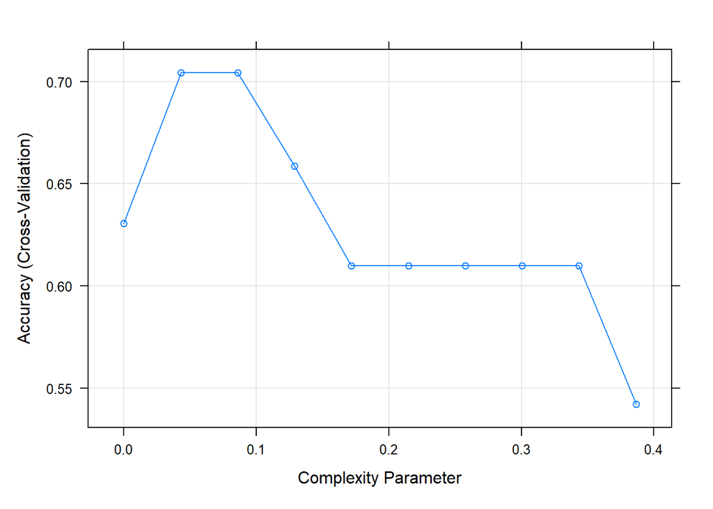

```r
plot(dtFit)
```

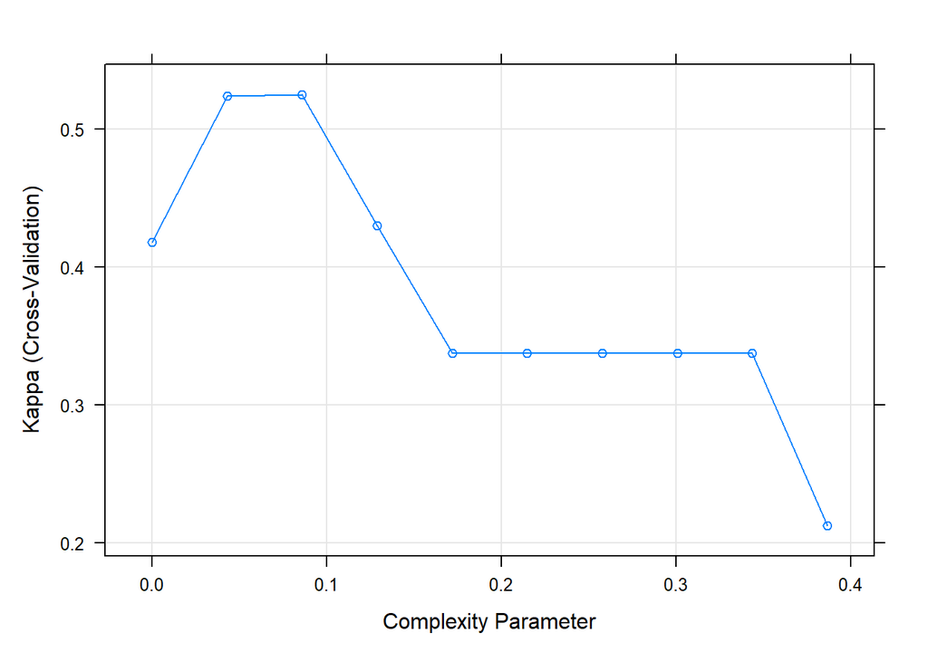

```r
plot(dtFit,metric="Kappa")
```

```r
test_pred <- predict(dtFit, dataTest)
confusionMatrix(test_pred, classTest)
```

```
## Confusion Matrix and Statistics
##
##           Reference
## Prediction  1  2  4
##          1 38  5  7
##          2  2 39  0
##          4 10  6 14
##
## Overall Statistics
##
##                Accuracy : 0.7521
##                  95% CI : (0.6654, 0.826)
##     No Information Rate : 0.4132
##     P-Value [Acc > NIR] : 3.91e-14
##
##                   Kappa : 0.6163
##
##  Mcnemar's Test P-Value : 0.04999
##
## Statistics by Class:
##
##                      Class: 1 Class: 2 Class: 4
## Sensitivity            0.7600   0.7800   0.6667
## Specificity            0.8310   0.9718   0.8400
## Pos Pred Value         0.7600   0.9512   0.4667
## Neg Pred Value         0.8310   0.8625   0.9231
## Prevalence             0.4132   0.4132   0.1736
## Detection Rate         0.3140   0.3223   0.1157
## Detection Prevalence   0.4132   0.3388   0.2479
## Balanced Accuracy      0.7955   0.8759   0.7533
```

```r
dtFeat = varImp(dtFit)$importance
dtFeat$gene = rownames(dtFeat)
dtFeatures = head(dtFeat[order(-dtFeat$Overall),]$gene,10)
print(dtFeatures)
```

```
##  [1] "BANF1"    "PRDX2"    "YBX1"     "PAM"      "CDC42EP1" "ATP5MC2"
##  [7] "PNKD"     "ATP5PD"   "S100A16"  "MAML3"
```

Try training decision tree on top 10 features.

```r
dataTrain_topfeat = dataTrain[,dtFeatures]
dataTest_topfeat = dataTest[,dtFeatures]
dtFit_topfeat <- train(dataTrain_topfeat, classTrain,
               method="rpart",
               tuneLength = 10,
               trControl=train_ctrl)
dtFit_topfeat
```

```
## CART
##
## 287 samples
##  10 predictor
##   3 classes: '1', '2', '4'
##
## No pre-processing
## Resampling: Cross-Validated (10 fold)
## Summary of sample sizes: 259, 259, 257, 258, 258, 258, ...
## Resampling results across tuning parameters:
##
##   cp          Accuracy   Kappa
##   0.00000000  0.6756568  0.4828727
##   0.04294479  0.6901806  0.5047418
##   0.08588957  0.6866092  0.4989150
##   0.12883436  0.6374713  0.3945599
##   0.17177914  0.6059360  0.3325810
##   0.21472393  0.6059360  0.3325810
##   0.25766871  0.6059360  0.3325810
##   0.30061350  0.6059360  0.3325810
##   0.34355828  0.6059360  0.3325810
##   0.38650307  0.5300739  0.1968939
##
## Accuracy was used to select the optimal model using the largest value.
## The final value used for the model was cp = 0.04294479.
```

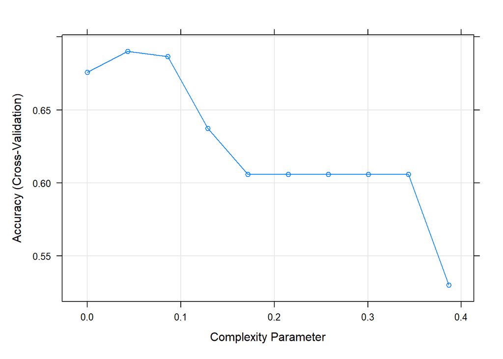

```r
plot(dtFit_topfeat)
```

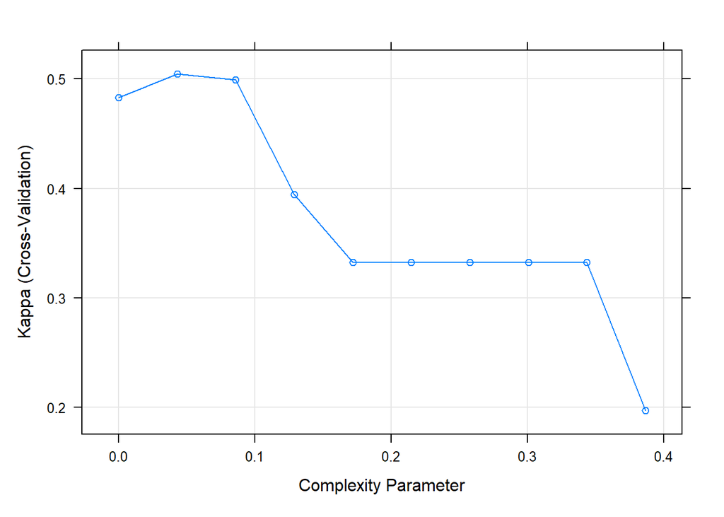

```r
plot(dtFit_topfeat,metric="Kappa")
```

```r
test_pred <- predict(dtFit_topfeat, dataTest_topfeat)
confusionMatrix(test_pred, classTest)
```

```
## Confusion Matrix and Statistics
##
##           Reference
## Prediction  1  2  4
##          1 38  5  7
##          2  2 39  0
##          4 10  6 14
##
## Overall Statistics
##
##                Accuracy : 0.7521
##                  95% CI : (0.6654, 0.826)
##     No Information Rate : 0.4132
##     P-Value [Acc > NIR] : 3.91e-14
##
##                   Kappa : 0.6163
##
##  Mcnemar's Test P-Value : 0.04999
##
## Statistics by Class:
##
##                      Class: 1 Class: 2 Class: 4
## Sensitivity            0.7600   0.7800   0.6667
## Specificity            0.8310   0.9718   0.8400
## Pos Pred Value         0.7600   0.9512   0.4667
## Neg Pred Value         0.8310   0.8625   0.9231
## Prevalence             0.4132   0.4132   0.1736
## Detection Rate         0.3140   0.3223   0.1157
## Detection Prevalence   0.4132   0.3388   0.2479
## Balanced Accuracy      0.7955   0.8759   0.7533
```

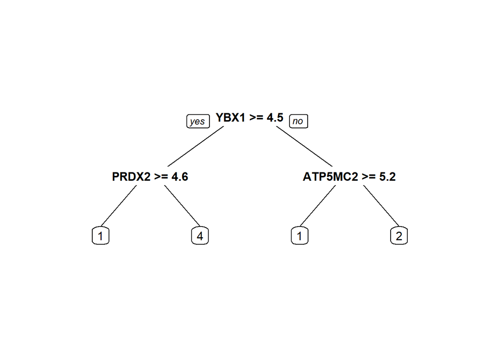

```r
prp(dtFit_topfeat$finalModel)
```

### Random Forest

```r
rfFit <- train(dataTrain, classTrain,
               method="rf",
               preProcess = c("center", "scale"),
               tuneLength=10,
               trControl=train_ctrl)
rfFit
```

```
## Random Forest
##
## 287 samples
## 168 predictors
##   3 classes: '1', '2', '4'
##
## Pre-processing: centered (168), scaled (168)
## Resampling: Cross-Validated (10 fold)
## Summary of sample sizes: 259, 259, 257, 258, 258, 258, ...
## Resampling results across tuning parameters:
##
##   mtry  Accuracy   Kappa
##     2   0.7805993  0.6243137
##    20   0.8463875  0.7438929
##    38   0.8362890  0.7294816
##    57   0.8364122  0.7320214
##    75   0.8397373  0.7375786
##    94   0.8400985  0.7375504
##   112   0.8192857  0.7027760
##   131   0.8192857  0.7026766
##   149   0.8086946  0.6868485
##   168   0.8122660  0.6913970
##
## Accuracy was used to select the optimal model using the largest value.
## The final value used for the model was mtry = 20.
```

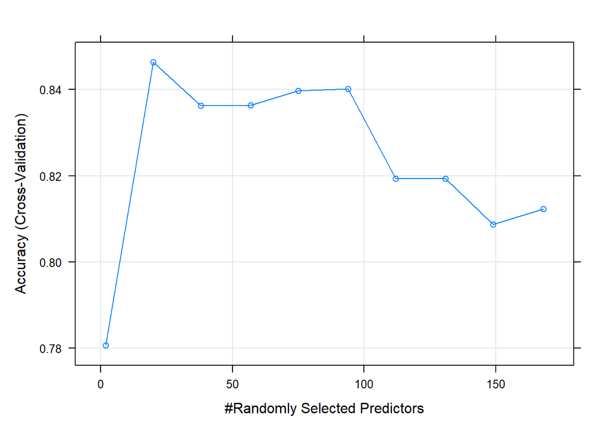

```r
plot(rfFit)
```

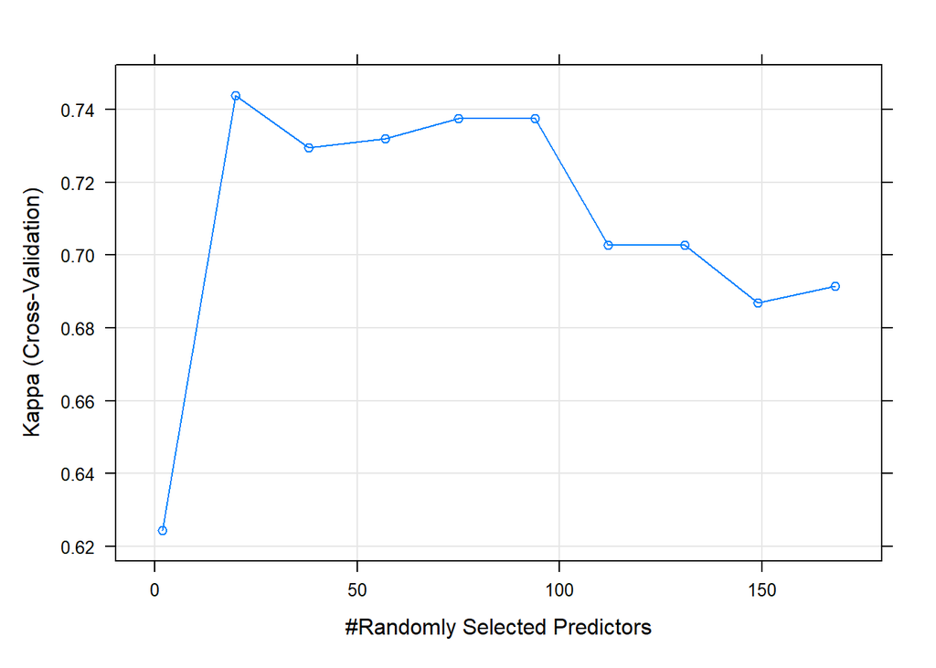

```r
plot(rfFit,metric="Kappa")
```

```r
test_pred <- predict(rfFit, dataTest)
confusionMatrix(test_pred, classTest)
```

```
## Confusion Matrix and Statistics
##
##           Reference
## Prediction  1  2  4
##          1 50  1  9
##          2  0 49  1
##          4  0  0 11
##
## Overall Statistics
##
##                Accuracy : 0.9091
##                  95% CI : (0.8432, 0.9537)
##     No Information Rate : 0.4132
##     P-Value [Acc > NIR] : < 2e-16
##
##                   Kappa : 0.8506
##
##  Mcnemar's Test P-Value : 0.01173
##
## Statistics by Class:
##
##                      Class: 1 Class: 2 Class: 4
## Sensitivity            1.0000   0.9800  0.52381
## Specificity            0.8592   0.9859  1.00000
## Pos Pred Value         0.8333   0.9800  1.00000
## Neg Pred Value         1.0000   0.9859  0.90909
## Prevalence             0.4132   0.4132  0.17355
## Detection Rate         0.4132   0.4050  0.09091
## Detection Prevalence   0.4959   0.4132  0.09091
## Balanced Accuracy      0.9296   0.9830  0.76190
```

```r
rfFeat = varImp(rfFit)$importance
rfFeat$gene = rownames(rfFeat)
rfFeatures = head(rfFeat[order(-rfFeat$Overall),]$gene,10)
print(rfFeatures)
```

```
##  [1] "YBX1"     "BANF1"    "CDC42EP1" "PRDX2"    "EEF2"     "ATF7IP"
##  [7] "OIP5.AS1" "PAM"      "VASP"     "ATP5MC2"
```

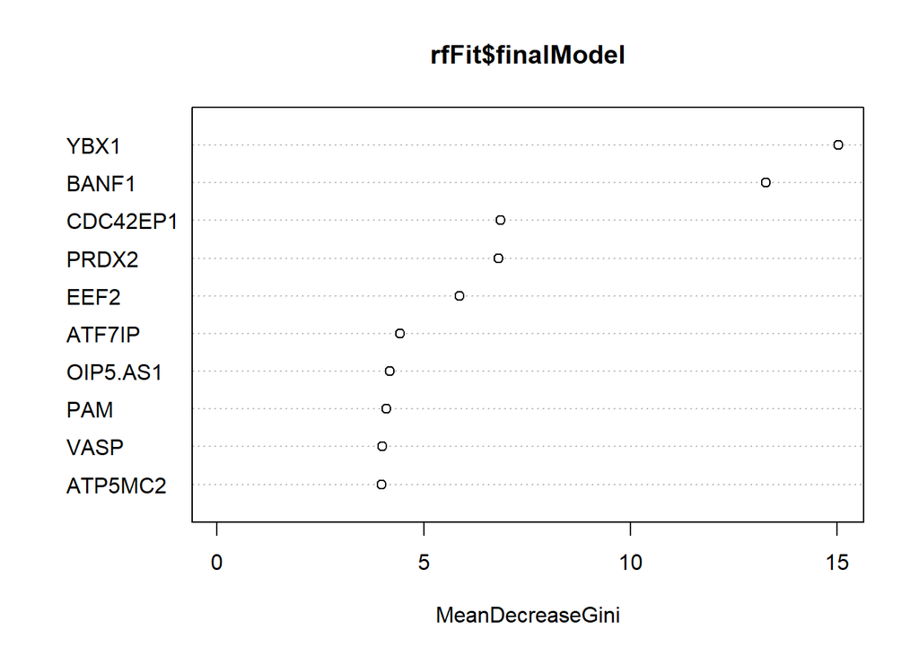

```r
varImpPlot(rfFit$finalModel,n.var = 10)
```

Try training random forest on top 10 features.

```r
dataTrain_topfeat = dataTrain[,rfFeatures]
dataTest_topfeat = dataTest[,rfFeatures]
rfFit_topfeat <- train(dataTrain_topfeat, classTrain,
               method="rf",
               tuneLength=10,
               trControl=train_ctrl)
rfFit_topfeat
```

```
## Random Forest
##
## 287 samples
##  10 predictor
##   3 classes: '1', '2', '4'
##
## No pre-processing
## Resampling: Cross-Validated (10 fold)
## Summary of sample sizes: 258, 258, 258, 258, 259, 258, ...
## Resampling results across tuning parameters:
##
##   mtry  Accuracy   Kappa
##    2    0.8357143  0.7299826
##    3    0.8286946  0.7188080
##    4    0.8357143  0.7327303
##    5    0.8253695  0.7172941
##    6    0.8182266  0.7051662
##    7    0.8149015  0.6999227
##    8    0.8147783  0.6996570
##    9    0.8289409  0.7240915
##   10    0.8290640  0.7244809
##
## Accuracy was used to select the optimal model using the largest value.
## The final value used for the model was mtry = 2.
```

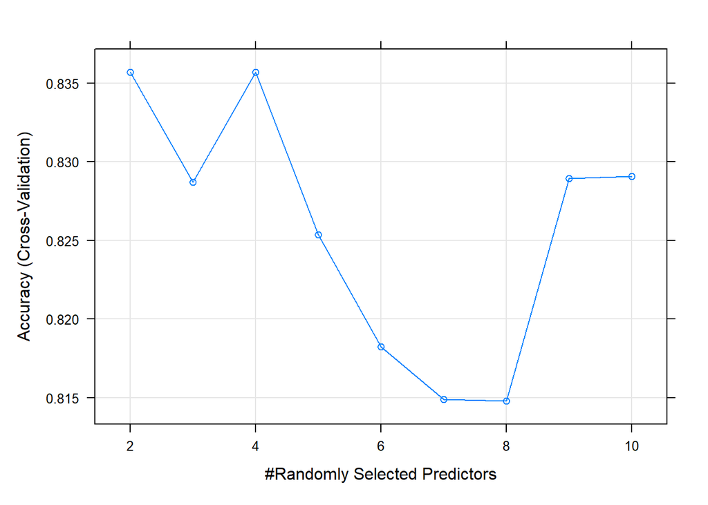

```r
plot(rfFit_topfeat)
```

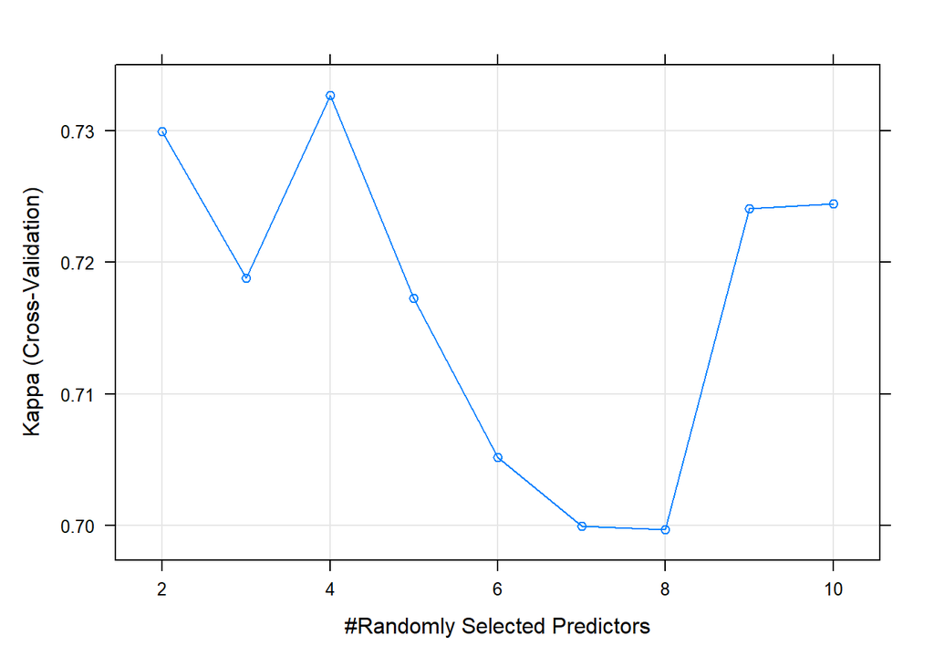

```r
plot(rfFit_topfeat,metric="Kappa")
```

```r
test_pred <- predict(rfFit_topfeat, dataTest_topfeat)
confusionMatrix(test_pred, classTest)
```

```
## Confusion Matrix and Statistics
##
##           Reference
## Prediction  1  2  4
##          1 45  1  4
##          2  0 49  1
##          4  5  0 16
##
## Overall Statistics
##
##                Accuracy : 0.9091
##                  95% CI : (0.8432, 0.9537)
##     No Information Rate : 0.4132
##     P-Value [Acc > NIR] : <2e-16
##
##                   Kappa : 0.8553
##
##  Mcnemar's Test P-Value : 0.5497
##
## Statistics by Class:
##
##                      Class: 1 Class: 2 Class: 4
## Sensitivity            0.9000   0.9800   0.7619
## Specificity            0.9296   0.9859   0.9500
## Pos Pred Value         0.9000   0.9800   0.7619
## Neg Pred Value         0.9296   0.9859   0.9500
## Prevalence             0.4132   0.4132   0.1736
## Detection Rate         0.3719   0.4050   0.1322
## Detection Prevalence   0.4132   0.4132   0.1736
## Balanced Accuracy      0.9148   0.9830   0.8560
```

### Support Vector Machine

Train SVMs using linear, polynomial and radial kernels and compare the accuracy attained.

```r
L_models <- train(dataTrain, classTrain,
                  method="svmLinear",
                  preProcess = c("center", "scale"),
                  tuneLength=5,
                  trControl=train_ctrl)
P_models <- train(dataTrain, classTrain,
                  method="svmPoly",
                  preProcess = c("center", "scale"),
                  tuneLength=5,
                  trControl=train_ctrl)

R_models <- train(dataTrain, classTrain,
                  method="svmRadial",
                  preProcess = c("center", "scale"),
                  tuneLength=5,
                  trControl=train_ctrl)

resamps <- resamples(list(Linear = L_models, Poly = P_models, Radial = R_models))
summary(resamps)
```

```
##
## Call:
## summary.resamples(object = resamps)
##
## Models: Linear, Poly, Radial
## Number of resamples: 10
##
## Accuracy
##             Min.   1st Qu.    Median      Mean   3rd Qu.      Max. NA's
## Linear 0.6785714 0.8583744 0.8620690 0.8492447 0.8879310 0.9333333    0
## Poly   0.8214286 0.8290230 0.8793103 0.8816092 0.9285714 0.9655172    0
## Radial 0.7931034 0.8583744 0.8797619 0.8850657 0.9205665 0.9655172    0
##
## Kappa
##             Min.   1st Qu.    Median      Mean   3rd Qu.      Max. NA's
## Linear 0.5097276 0.7733189 0.7784095 0.7601284 0.8191139 0.8915009    0
## Poly   0.7077244 0.7281523 0.8024934 0.8088157 0.8861732 0.9450758    0
## Radial 0.6520000 0.7735133 0.8068483 0.8137001 0.8719136 0.9440154    0
```

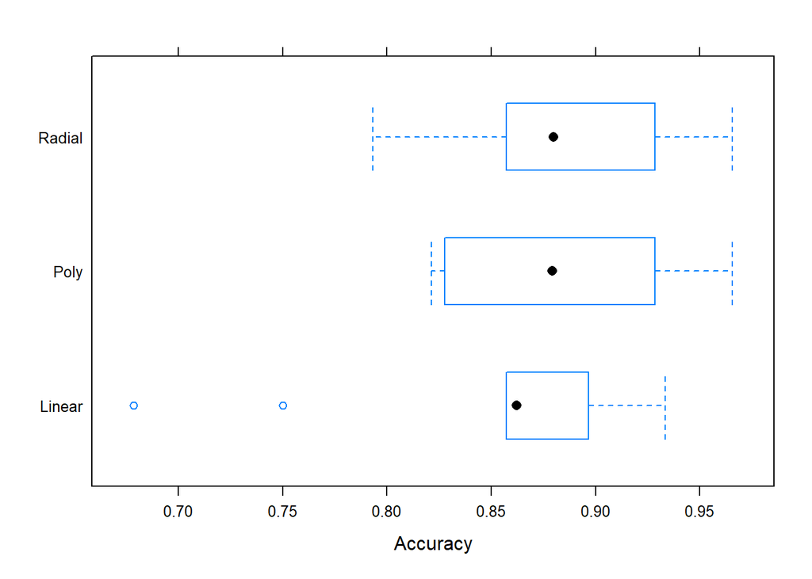

```r
bwplot(resamps, metric = "Accuracy")
```

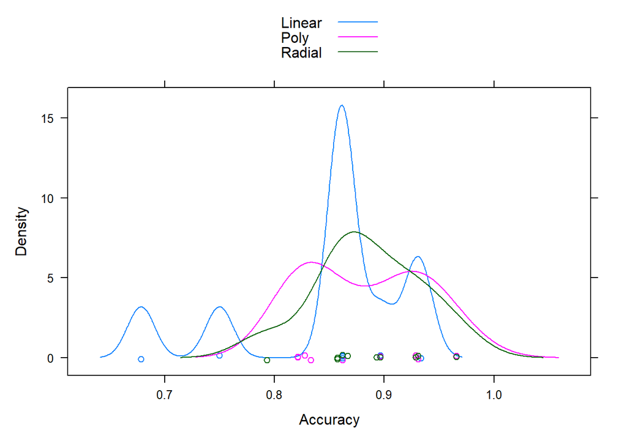

```r
densityplot(resamps, metric = "Accuracy",auto.key=TRUE)
```

```r
test_pred <- predict(R_models, dataTest)
confusionMatrix(test_pred, classTest)
```

```
## Confusion Matrix and Statistics
##
##           Reference
## Prediction  1  2  4
##          1 49  1  2
##          2  0 48  1
##          4  1  1 18
##
## Overall Statistics
##
##                Accuracy : 0.9504
##                  95% CI : (0.8952, 0.9816)
##     No Information Rate : 0.4132
##     P-Value [Acc > NIR] : <2e-16
##
##                   Kappa : 0.9208
##
##  Mcnemar's Test P-Value : 0.7212
##
## Statistics by Class:
##
##                      Class: 1 Class: 2 Class: 4
## Sensitivity            0.9800   0.9600   0.8571
## Specificity            0.9577   0.9859   0.9800
## Pos Pred Value         0.9423   0.9796   0.9000
## Neg Pred Value         0.9855   0.9722   0.9703
## Prevalence             0.4132   0.4132   0.1736
## Detection Rate         0.4050   0.3967   0.1488
## Detection Prevalence   0.4298   0.4050   0.1653
## Balanced Accuracy      0.9689   0.9730   0.9186
```

```r
svmFeat = varImp(R_models)$importance
svmFeatures = head(rownames(svmFeat[order(-rowSums(svmFeat)),]),10)
print(svmFeatures)
```

```
##  [1] "YBX1"     "BANF1"    "CDC42EP1" "EEF2"     "ATF7IP"   "PRDX2"
##  [7] "OIP5.AS1" "NACA3P"   "ATP5MC2"  "VASP"
```

Try training SVM on top 10 features.

```r
dataTrain_topfeat = dataTrain[,svmFeatures]
dataTest_topfeat = dataTest[,svmFeatures]
R_models_topfeat <- train(dataTrain_topfeat, classTrain,
               method="svmRadial",
               tuneLength=10,
               trControl=train_ctrl)
R_models_topfeat
```

```
## Support Vector Machines with Radial Basis Function Kernel
##
## 287 samples
##  10 predictor
##   3 classes: '1', '2', '4'
##
## No pre-processing
## Resampling: Cross-Validated (10 fold)
## Summary of sample sizes: 257, 258, 258, 259, 258, 259, ...
## Resampling results across tuning parameters:
##
##   C       Accuracy   Kappa
##     0.25  0.8182759  0.6965768
##     0.50  0.8676601  0.7841209
##     1.00  0.8606404  0.7750526
##     2.00  0.8537356  0.7640378
##     4.00  0.8677833  0.7872954
##     8.00  0.8396962  0.7444136
##    16.00  0.8153038  0.7051611
##    32.00  0.8256568  0.7203283
##    64.00  0.8433908  0.7491268
##   128.00  0.8364860  0.7386461
##
## Tuning parameter 'sigma' was held constant at a value of 0.06868854
## Accuracy was used to select the optimal model using the largest value.
## The final values used for the model were sigma = 0.06868854 and C = 4.
```

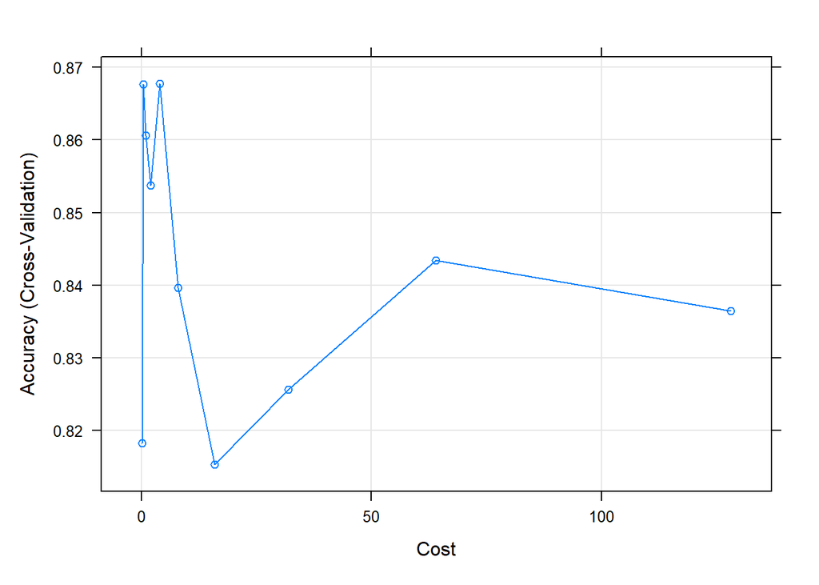

```r
plot(R_models_topfeat)
```

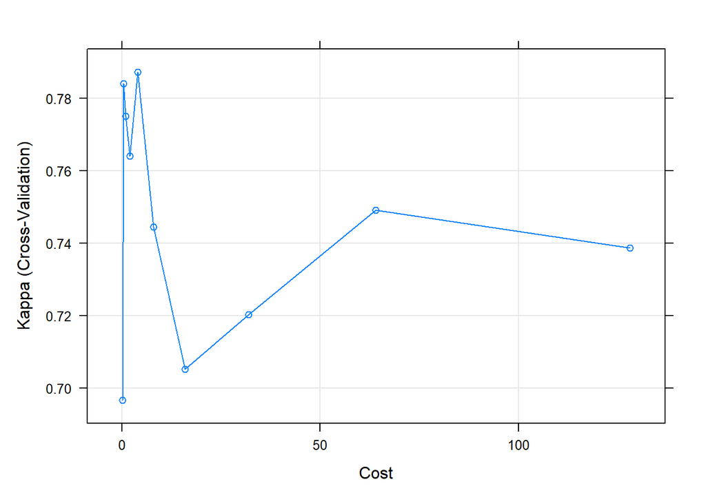

```r
plot(R_models_topfeat,metric="Kappa")
```

```r
test_pred <- predict(R_models_topfeat, dataTest_topfeat)
confusionMatrix(test_pred, classTest)
```

```
## Confusion Matrix and Statistics
##
##           Reference
## Prediction  1  2  4
##          1 39  3  5
##          2  2 46  1
##          4  9  1 15
##
## Overall Statistics
##
##                Accuracy : 0.8264
##                  95% CI : (0.747, 0.8892)
##     No Information Rate : 0.4132
##     P-Value [Acc > NIR] : <2e-16
##
##                   Kappa : 0.7272
##
##  Mcnemar's Test P-Value : 0.719
##
## Statistics by Class:
##
##                      Class: 1 Class: 2 Class: 4
## Sensitivity            0.7800   0.9200   0.7143
## Specificity            0.8873   0.9577   0.9000
## Pos Pred Value         0.8298   0.9388   0.6000
## Neg Pred Value         0.8514   0.9444   0.9375
## Prevalence             0.4132   0.4132   0.1736
## Detection Rate         0.3223   0.3802   0.1240
## Detection Prevalence   0.3884   0.4050   0.2066
## Balanced Accuracy      0.8337   0.9389   0.8071
```

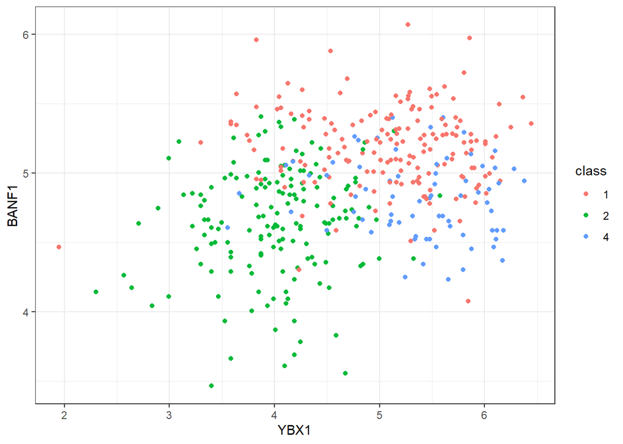

```r
topfeat = svmFeatures[1]
secondfeat = svmFeatures[2]
plot.df = data.frame(topfeature=cuomoData[,topfeat],secondfeature=cuomoData[,secondfeat],class=as.factor(cuomoClass))
ggplot(plot.df,aes(x=topfeature,y=secondfeature,color=class))+geom_point()+xlab(topfeat)+ylab(secondfeat)+theme_bw()
```

## Conclusions

We can compare the accuracy of all the models as well as the features chosen.

```r
resamps <- resamples(list(kNN = knnFit, Dtree = dtFit, RF = rfFit, SVM_poly = P_models, SVM_radial = R_models))
summary(resamps)
```

```
##
## Call:
## summary.resamples(object = resamps)
##
## Models: kNN, Dtree, RF, SVM_poly, SVM_radial
## Number of resamples: 10
##
## Accuracy
##                 Min.   1st Qu.    Median      Mean   3rd Qu.      Max. NA's
## kNN        0.6666667 0.6813424 0.7321429 0.7315681 0.7586207 0.8275862    0
## Dtree      0.6206897 0.6696429 0.6948276 0.7044007 0.7216749 0.8571429    0
## RF         0.7500000 0.7961823 0.8452381 0.8463875 0.8956281 0.9655172    0
## SVM_poly   0.8214286 0.8290230 0.8793103 0.8816092 0.9285714 0.9655172    0
## SVM_radial 0.7931034 0.8583744 0.8797619 0.8850657 0.9205665 0.9655172    0
##
## Kappa
##                 Min.   1st Qu.    Median      Mean   3rd Qu.      Max. NA's
## kNN        0.4603854 0.4923469 0.5643154 0.5646905 0.6118504 0.7216891    0
## Dtree      0.3817829 0.4586192 0.5227312 0.5250801 0.5680757 0.7642105    0
## RF         0.5840164 0.6619724 0.7424602 0.7438929 0.8269980 0.9440154    0
## SVM_poly   0.7077244 0.7281523 0.8024934 0.8088157 0.8861732 0.9450758    0
## SVM_radial 0.6520000 0.7735133 0.8068483 0.8137001 0.8719136 0.9440154    0
```

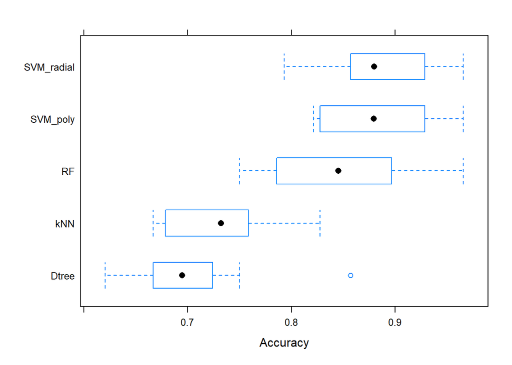

```r
bwplot(resamps, metric = "Accuracy")
```

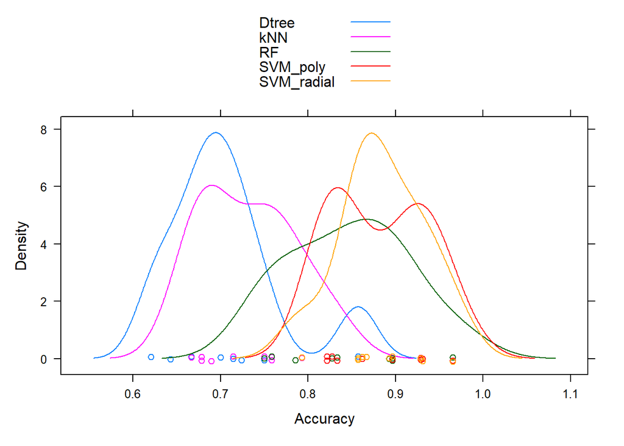

```r
densityplot(resamps, metric = "Accuracy",auto.key=TRUE)
```

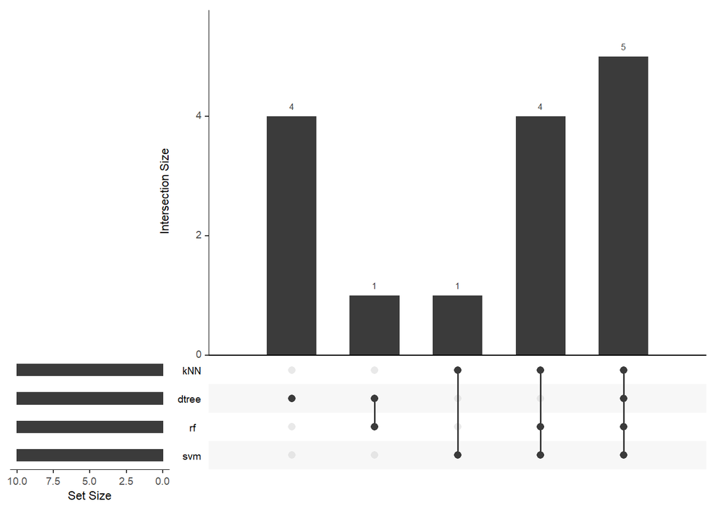

```r
feature.list = list('kNN'=knnFeatures,'dtree'=dtFeatures,'rf'=rfFeatures,'svm'=svmFeatures)
print(upset(fromList(feature.list)))
```

```r
print(intersect(knnFeatures,intersect(dtFeatures,intersect(rfFeatures,svmFeatures))))
```

```
## [1] "YBX1"     "BANF1"    "CDC42EP1" "PRDX2"    "ATP5MC2"
```

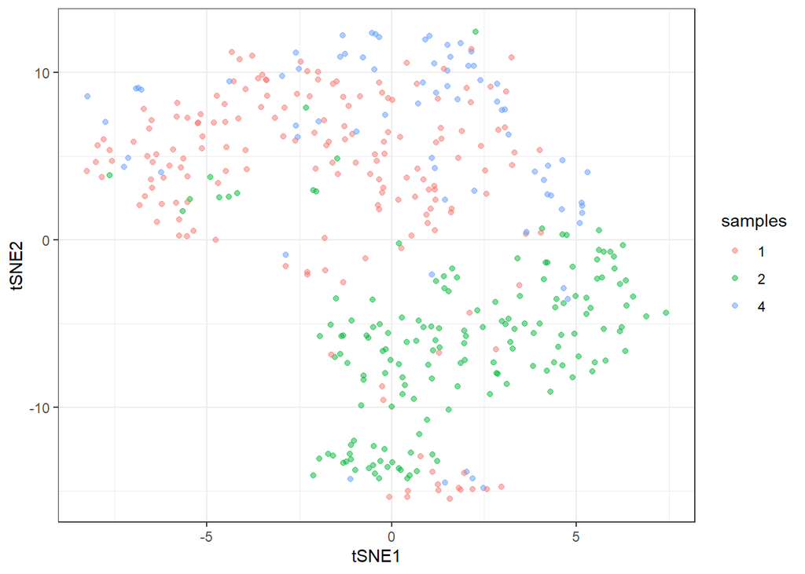

```r
cuomoData_topfeatures = cuomoData[,intersect(knnFeatures,intersect(dtFeatures,intersect(rfFeatures,svmFeatures)))]
cuomoTsne_topfeatures <- Rtsne(cuomoData_topfeatures, check_duplicates=FALSE, pca=TRUE, perplexity=50, theta=0.5, dims=2)
print(cuomoTsne_topfeatures$Y %>%
  as.data.frame() %>%
  rename(tSNE1=V1,  tSNE2=V2) %>%
  mutate( samples=as.character(cuomoClass) )%>%
  ggplot() +
  geom_point( mapping = aes(x=tSNE1, y=tSNE2, color=samples), alpha=0.5) +
  theme_bw())
```